# RNA-seq data analysis

Gene set analyses

Kim Dill-McFarland, kadm@uw.edu

version September 28, 2022

# Overview

This document covers gene set related analyses of RNAseq data in the R package `SEARchways`. This pipeline explores differentially expressed genes (see [voom to DEG](https://bigslu.github.io/tutorials/RNAseq/3.RNAseq_voom.to.DEG.html)) and gene co-expression modules (see [RNAseq modules](https://bigslu.github.io/tutorials/RNAseq/4.RNAseq_modules.html)). The goal is to determine pathways associated with genes and modules significantly impacted by viral infection or asthma status. The example data are human, bulk, paired-end RNA-seq, but this pipeline can be applied to other organisms or single-read libraries.

# 0. Setup

## Software

This pipeline should be completed in [R](https://cran.r-project.org/) and [RStudio](https://www.rstudio.com/products/rstudio/download/). You should also install the following packages.

```r
#CRAN packages
install.packages(c("tidyverse", "WGCNA"))

#Bioconductor packages
install.packages("BiocManager")
BiocManager::install(c("edgeR", "limma", "patchwork"))

#GitHub packages
install.packages("devtools")
devtools::install_github("BIGslu/BIGverse")
```

And load them into your current R session.

```r
library(tidyverse)
library(BIGverse)
library(limma)
library(WGCNA)
library(patchwork)

set.seed(651)
```

## Example data

Example data were obtained from virus-stimulated human plasmacytoid dendritic cells. Actual patient identifiers and metadata have been altered for this tutorial.

> Dill-McFarland KA, Schwartz JT, Zhao H, Shao B, Fulkerson PC, Altman MC, Gill MA. 2022. Eosinophil-mediated suppression and Anti-IL-5 enhancement of plasmacytoid dendritic cell interferon responses in asthma. J Allergy Clin Immunol. Epub ahead of print. doi: 10.1016/j.jaci.2022.03.025. — [GitHub](https://github.com/altman-lab/P259_pDC_public)

Specifically, this tutorial uses RNAseq data processed using our [SEAsnake](https://bigslu.github.io/SEAsnake/vignette/SEAsnake_vignette.html) and [counts to voom](https://bigslu.github.io/tutorials/RNAseq/2.RNAseq_counts.to.voom.html) pipelines, resulting in voom-normalized, log2 counts per million (CPM) expression and associated sample metadata in a `limma EList` object in the `data_clean/` directory. These data are available in the `kimma` package within the `example.voom` data object.

# 1. Load data

All counts, gene, and sample metadata are contained in a single object in the `kimma` package. Note that these data contain only 1000 genes from the full data set create in our counts to voom pipeline. This is to reduce computational time.

```r
#Extract and rename data object
dat <- kimma::example.voom
```

# 2. Differential gene expression

First, we determine genes associated with viral infection and/or asthma in this data set. You can see more about model fitting in our [voom to DEG](https://bigslu.github.io/tutorials/RNAseq/3.RNAseq_voom.to.DEG.html) tutorial.

```r
virus_lme <- kmFit(dat = dat,
                   model = "~ virus*asthma + (1|ptID)",
                   run.lme = TRUE,
                   use.weights = TRUE)
```

```
## lme/lmerel model: expression~virus*asthma+(1|ptID)
```

```
## Input: 12 libraries from 6 unique patients
```

```
## Model: 12 libraries
```

```
## Complete: 1000 genes
```

```
## Failed: 0 genes
```

## 2.1 Hypergeometric enrichment

There are hundreds of genes significant for virus and/or asthma in this data set (FDR < 0.05). This is too many to assess individuals so we use enrichment to determine pathways associated with these genes.

```r
summarise_kmFit(virus_lme$lme)
```

```
## # A tibble: 5 × 7
##   variable             fdr_0.05 fdr_0.1 fdr_0.2 fdr_0.3 fdr_0.4 fdr_0.5
##   <fct>                   <int>   <int>   <int>   <int>   <int>   <int>
## 1 (1 | ptID)                  7       9      21      24      33     124
## 2 asthma                     69      98     140     204     284     355
## 3 virus                     266     314     397     468     566     628
## 4 virus:asthma               17      33      46      77      89     106
## 5 total (nonredundant)      316     384     493     590     710     797
```

### `BIGprofiler`

`SEARchway` contains two functions to run enrichment. The first `BIGprofiler` employs `clusterProfiler` to run Fisher’s exact tests of your genes of interest against any gene set data base available in the Broad Molecular Signatures Database ([MSigDB](https://www.gsea-msigdb.org/gsea/msigdb/collections.jsp)). Here, let’s run the virus significant genes against the Hallmark data base.

```r
#Virus significant genes
genes.virus <- virus_lme$lme %>%
  filter(variable == "virus" & FDR < 0.05) %>%
  pull(hgnc_symbol)

enrich.virus <- BIGprofiler(gene_list = list("virus" = genes.virus),
                            ID = "SYMBOL",
                            category = "H")
```

```
## [1] "virus"
```

The output includes:

- `group`: Name identifier for genes of interest
- `size_group`: Total genes in each group
- `gs_cat`: Gene set data base category
- `gs_subcat`: Gene set data base subcategory
- `size_cat.subcat`: Total genes in data base category/subcategory
- `group_in_cat.subcat`: Total significant genes in data base category/subcategory e.g. how many of your genes of interest are present in the data base
- `pathway`: Gene set name
- `size_pathway`: Total genes in gene set (K)
- `group_in_pathway`: Total significant genes in gene set (k)
- `k/K`: group_in_pathway / size_pathway, a commonly used metric of enrichment
- `pval`: P-value
- `FDR`: FDR corrected P-value
- `qvalue`: q-value
- `genes`: List of significant genes in gene set (not shown below for length)

The results show that there is 1 pathway enriched in virus significant genes at FDR < 0.05.

```r
enrich.virus %>%
  filter(FDR < 0.05) %>%
  select(-genes)
```

```
##   group size_group gs_cat gs_subcat size_cat.subcat group_in_cat.subcat
## 1 virus        266      H                      4383                  92
##                              pathway size_pathway group_in_pathway  k/K
## 1 HALLMARK_INTERFERON_GAMMA_RESPONSE          200               18 0.09
##           pval          FDR      qvalue
## 1 1.020391e-07 4.897876e-06 4.83343e-06
```

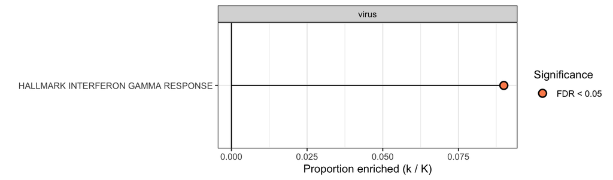

```r
plot_enrich(enrich.virus,
            fdr.cutoff = 0.5, fdr.colors = c(0.05, 0.5))
```

You can also look at multiple variables by inputing a data frame (`gene_df`) with the variable in 1 column and the significant genes in another. Note that the plot shows non-significant results for one variable or the other. This can be turned off with `show.overlap = FALSE`.

```r
gene_df <- virus_lme$lme %>%
  filter(FDR < 0.05 & variable %in% c("virus","asthma")) %>%
  select(variable, hgnc_symbol)
head(gene_df)
```

```
## # A tibble: 6 × 2
##   variable hgnc_symbol
##   <chr>    <chr>
## 1 virus    HS3ST1
## 2 asthma   ITGA3
## 3 asthma   PAF1
## 4 virus    HIVEP2
## 5 virus    TACC3
## 6 asthma   TACC3
```

```r
enrich.all <- BIGprofiler(gene_df = gene_df,
                          ID = "SYMBOL",
                          category = "H")
```

```
## [1] "virus"
## [1] "asthma"
```

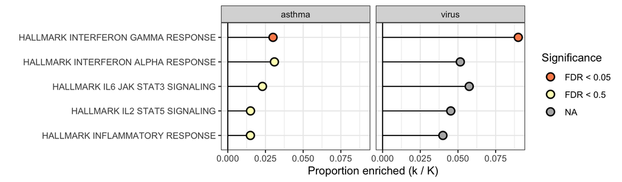

```r
plot_enrich(enrich.all,
            fdr.cutoff = 0.5, fdr.colors = c(0.05, 0.5))
```

#### What about directionality?

This type of enrichment does not address whether genes are up or down-regulated, just that they are significant in some way. Thus, if you would like to know direction, you need to create subsets like `virus.up` and `virus.down`, then run enrichment on the lists separately. This should be done with caution as not all gene sets have concordant directionality and shorter gene lists are less likely to be significant in any pathway.

### `BIGenrichr`

The other enrichment function in `SEARchways` is `BIGenrichr`, which runs a similar test but through the `enrichr` package and gene set data bases.

```r
enrich.virus2 <- BIGenrichr(gene_list = list("virus" = genes.virus),
                          ID = "SYMBOL",
                          dbs = "MSigDB_Hallmark_2020")
```

```
## Welcome to enrichR
## Checking connection ...
```

[output not shown]

```
## Uploading data to Enrichr... Done.
##   Querying MSigDB_Hallmark_2020... Done.
## Parsing results... Done.
```

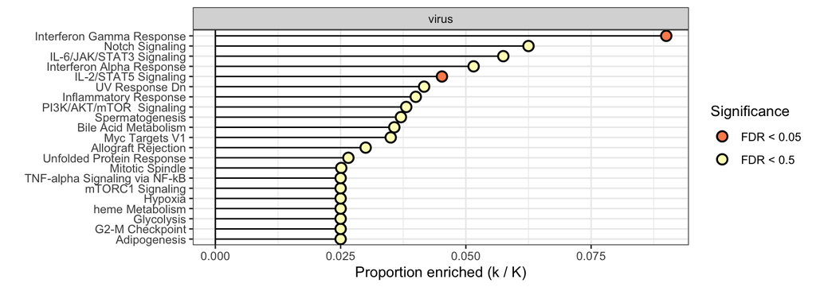

```r
plot_enrich(enrich.virus2$MSigDB_Hallmark_2020,
            fdr.cutoff = 0.5, fdr.colors = c(0.05, 0.5))
```

You will notice a lot more gene sets in the `enrichr` results. This package uses a slightly different statistic than `clusterProfiler` so you are likely to see different results, particularly at high FDR. For more information see https://maayanlab.cloud/Enrichr/

## 2.2 Gene set enrichment analysis (GSEA)

Another gene set related analysis is GSEA. This method uses fold change values of *all* genes in the data set instead of having you pre-define a significant list of genes. GSEA, thus, can find significant pathways with no individually significant genes in them. Instead, smaller up (or down) regulations of many genes can drive overall significance of a pathway.

`BIGsea` runs GSEA with parameters similar to `BIGprofiler` only now the input is log fold change (named `estimate` in the `kimma` output).

```r
gene_df2 <- virus_lme$lme %>%
  filter(variable %in% c("virus", "asthma")) %>%
  select(variable, hgnc_symbol, estimate)
head(gene_df2)
```

```
## # A tibble: 6 × 3
##   variable hgnc_symbol estimate
##   <chr>    <chr>          <dbl>
## 1 virus    C1orf112       0.425
## 2 asthma   C1orf112       0.783
## 3 virus    STPG1          0.369
## 4 asthma   STPG1          0.225
## 5 virus    HS3ST1        -0.858
## 6 asthma   HS3ST1        -0.130
```

```r
gsea.all <- BIGsea(gene_df = gene_df2,
                          ID = "SYMBOL",
                          category = "H")
```

```
## virus
```

```
## Warning in preparePathwaysAndStats(pathways, stats, minSize, maxSize, gseaParam, : There are ties in the preranked stats (0.7% of the list).
## The order of those tied genes will be arbitrary, which may produce unexpected results.
```

```
## asthma
```

```
## Warning in preparePathwaysAndStats(pathways, stats, minSize, maxSize, gseaParam, : There are ties in the preranked stats (0.7% of the list).
## The order of those tied genes will be arbitrary, which may produce unexpected results.
```

Note the warning about ties in the data. This means that 2 or more genes have an identical log fold change value and thus, GSEA must randomly determine their rank order relative to each other. This is not an issue because we’ve already set a random seed for reproducibility. However, if there are a lot of ties in your data, like > 10%, this may indicate a need to re-assess your linear model to better represent differences across the data.

Similarly, we can plot the GSEA results with `BIGpicture`. Until simple enrichment, GSEA shows directionality such as here where IFN gamma response is up-regulated in response to virus. Remember to define your variable order with `factor` in the original data if you want something other than alphabetical as this determines whether the fold change values are A-B or B-A.

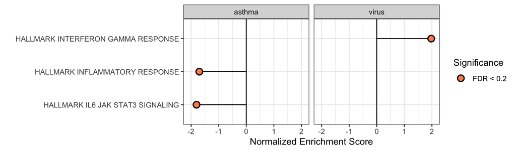

```r
plot_gsea(gsea.all,
          fdr.cutoff = 0.2)
```

### What if I have more than 2 groups to compare?

GSEA can only support pairwise comparison. Thus, if you have a variable of interest with 3 or more levels, you need to run each pairwise comparison of interest separately. You can access this data in `kimma` with `run.contrasts = TRUE`. This is also true for interaction terms, where the model estimate is not a simple fold change.

# 3. Module annotation

Gene set analyses can also be used to assign function to gene co-expression modules. For more information on module building, see our [RNAseq module tutorial](https://bigslu.github.io/tutorials/RNAseq/4.RNAseq_modules.html).

```r
#Define significant genes
genes.interact <- virus_lme$lme %>%
  filter(variable == "virus:asthma" & FDR < 0.2) %>%
  pull(gene)

genes.main <- virus_lme$lme %>%
  filter(variable %in% c("virus", "asthma") & FDR < 0.2) %>%
  pull(gene)

genes.all <- unique(c(genes.interact, genes.main))

fit <- fit_modules(dat = kimma::example.voom,
                   genes = genes.all,
                   powerVector=c(1:30),
                   networkType = "signed",
                   nThread = 4)

mod.p14 <- make_modules(fit,
                        sft.value = 14,
                        minModuleSize = 20,
                        maxBlockSize = 500,
                        deepSplit = 2,
                        networkType = "signed",
                        mods.mean = TRUE, mods.eigen = TRUE, david = TRUE,
                        nThread = 4)
```

The `SEARchways` function can be applied to module results from `RNAetc` like so.

## 3.1 Hypergeometric enrichment

We see several pathways enrichment in some of the modules.

```r
mod_df <- mod.p14$mods %>%
  select(module.char, hgnc_symbol)
head(mod_df)
```

```
##   module.char hgnc_symbol
## 1          05      HS3ST1
## 2          04       ITGA3
## 3          01    BAIAP2L1
## 4          04        DBF4
## 5          07        PAF1
## 6          02         CD9
```

```r
enrich.mod <- BIGprofiler(gene_df = mod_df,
                          ID = "SYMBOL",
                          category = "H")
```

```
## [1] "05"
## [1] "04"
## [1] "01"
## [1] "07"
## [1] "02"
## [1] "06"
## [1] "08"
## [1] "03"
## [1] "00"
```

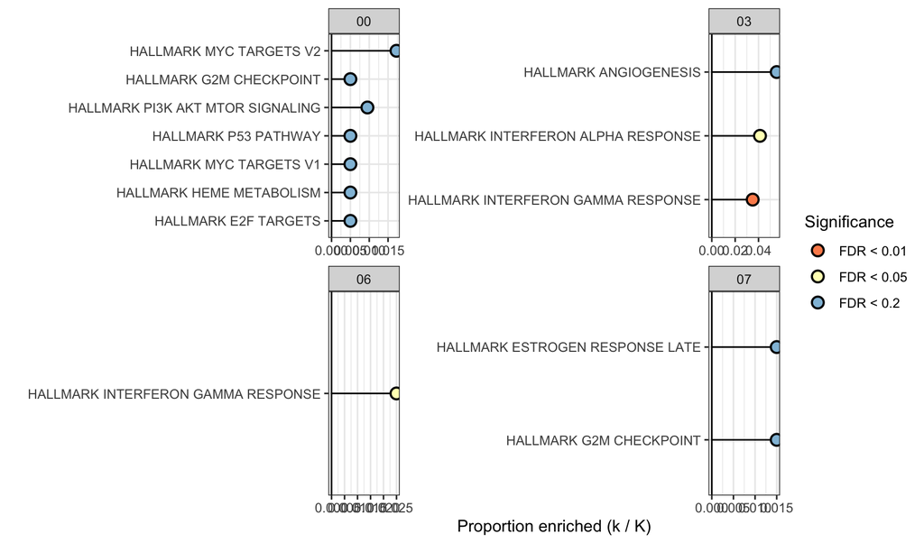

```r
plot_enrich(enrich.mod, fdr.cutoff = 0.2,
            show.overlap = FALSE)
```

# 4. STRING networks

The [STRING](https://string-db.org/) protein-protein interaction network data base is a useful tool for visualizing genes of interest. We have incorporated this visualization with `SEARchways` in order to facilitate annotation of the a STRING network with significant pathways.

For example, we plot the virus significant genes and color by significant hypergeometric enrichment from `BIGprofiler`.

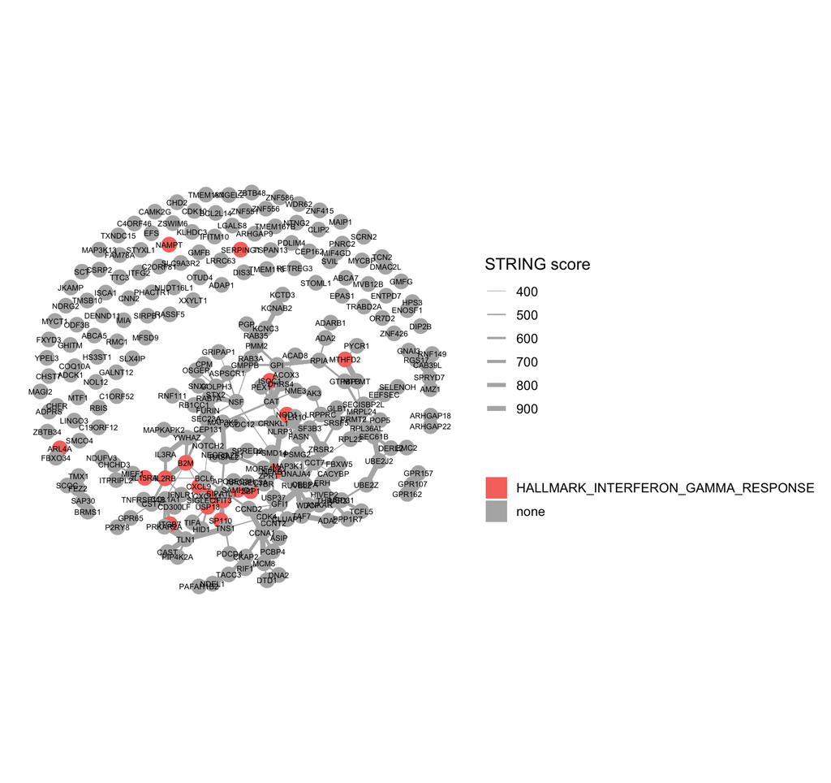

```r
#Map gene to STRING
map <- map_string(genes = genes.virus)
#plot
plot_string(map = map,
            enrichment = enrich.virus, fdr.cutoff = 0.05)
```

This network is pretty big so let’s cut if down to just genes with at least 1 connection.

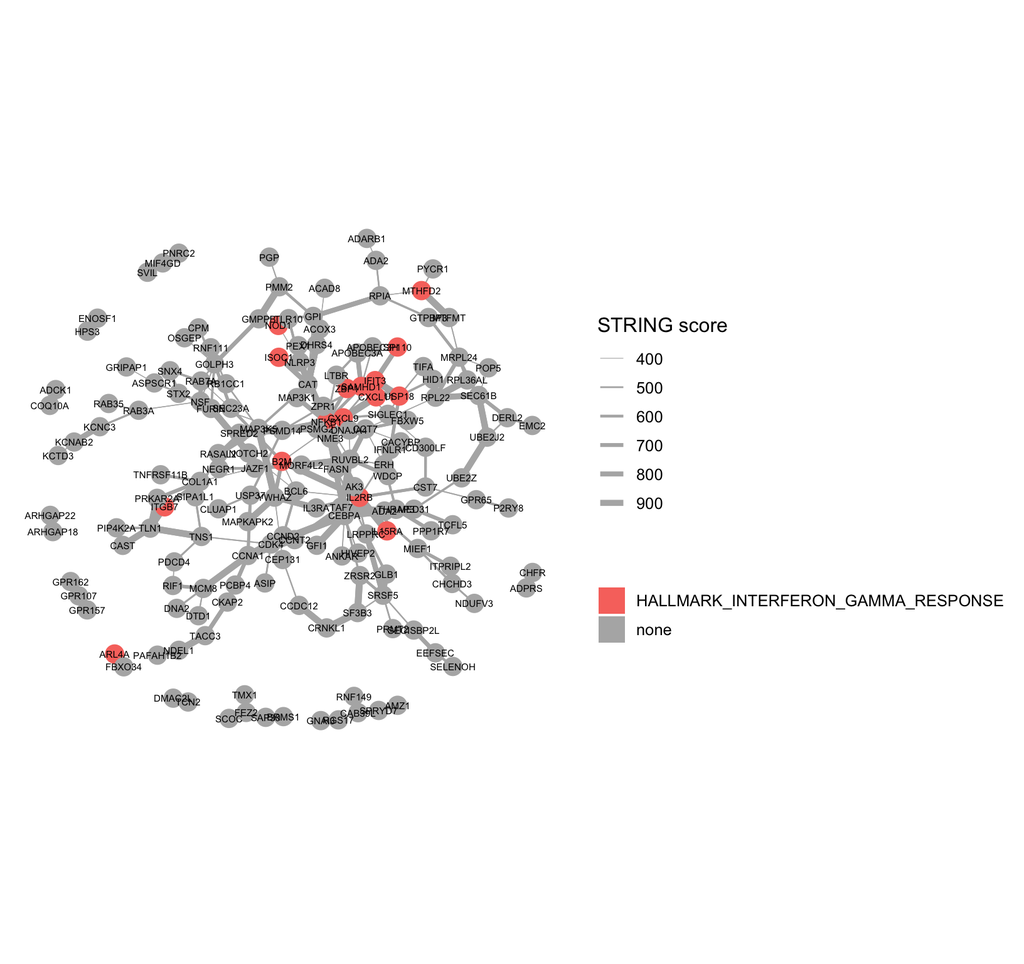

```r
plot_string(map = map,
            enrichment = enrich.virus, fdr.cutoff = 0.05,
            discard = "orphan")
```

Or we could color by GSEA results from `BIGsea`.

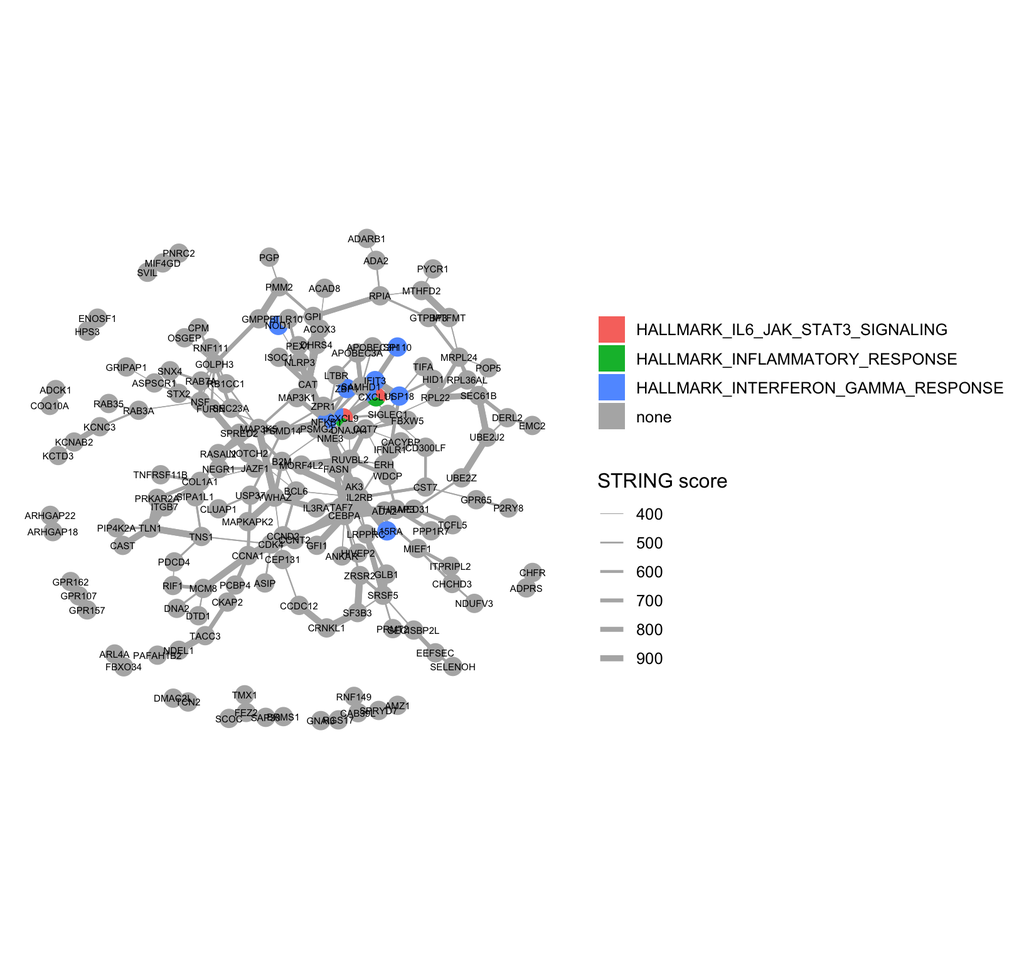

```r
gsea.virus <- gsea.all %>%
  filter(group == "virus")

plot_string(map = map,
            enrichment = gsea.all, fdr.cutoff = 0.2,
            discard = "orphan")
```

# *Navigation*

- Previous tutorial: [RNAseq modules](https://bigslu.github.io/tutorials/RNAseq/4.RNAseq_modules.html)
- [Index](https://bigslu.github.io/tutorials/)